# Part I - (Dataset Exploration Title)

```python
# check for null values
df.isna().sum()
```

```
duration_sec                  0
start_time                    0
end_time                      0
start_station_id            197
start_station_name          197
start_station_latitude        0
start_station_longitude       0
end_station_id              197
end_station_name            197
end_station_latitude          0
end_station_longitude         0
bike_id                       0
user_type                     0
member_birth_year          8265
member_gender              8265
bike_share_for_all_trip       0
dtype: int64
```

```python
#drop rows with null values
df.dropna(inplace=True)
```

```python
# convert column 'start_time','end_time','bike_id'to their correct data type
df['start_time']= pd.to_datetime(df['start_time'], format='%Y/%m/%d %H:%M:%S')
df['end_time']= pd.to_datetime(df['end_time'], format='%Y/%m/%d %H:%M:%S')
df['bike_id']= df['bike_id'].astype(str)
```

```python
# create new columns 'duration_min','start_hour','start_month','start_day'
df['start_hour']= df['start_time'].dt.hour
df['start_month'] = df['start_time'].dt.month_name()
df['start_day'] = df['start_time'].dt.day_name()

# create new columns 'duration_min','end_hour','end_month','end_day'
df['end_hour']= df['end_time'].dt.hour
df['end_month'] = df['end_time'].dt.month_name()
df['end_day'] = df['end_time'].dt.day_name()
```

```python
# derive a new column which is the difference between 'start_time' and 'ended_time' in minutes called 'duration_min'....rounded up to the nearest minute
df['duration_min']= round(df['duration_sec']/60.0)

#convert column'duration_min' to int datatype from float datatype
df['duration_min'] = df['duration_min'].astype('int64')
```

```python
#convert 'user_type' datatype to categorical
df['user_type']= df['user_type'].astype('category')
```

```python
#rearrange the column
df= df[['duration_sec', 'start_time','start_hour','start_day','start_month','end_time','end_hour','end_day','end_month','duration_min', 'start_station_id','start_station_name', 'start_station_latitude','start_station_longitude', 'end_station_id', 'end_station_name','end_station_latitude', 'end_station_longitude', 'bike_id', 'user_type','member_birth_year', 'member_gender','bike_share_for_all_trip']]
```

```python
year = df['member_birth_year']
df['age_diff'] = pd.DataFrame(2023 - year)
```

```python
#change 'age_diff' to an int type
df['age_diff']= df['age_diff'].astype('int64')
```

```python
df
```

|  | duration_sec | start_time | start_hour | start_day | start_month | end_time | end_hour | end_day | end_month | duration_min | ... | end_station_id | end_station_name | end_station_latitude | end_station_longitude | bike_id | user_type | member_birth_year | member_gender | bike_share_for_all_trip | age_diff |
| --- | --- | --- | --- | --- | --- | --- | --- | --- | --- | --- | --- | --- | --- | --- | --- | --- | --- | --- | --- | --- | --- |
| 0 | 52185 | 2019-02-28 17:32:10.145 | 17 | Thursday | February | 2019-03-01 08:01:55.975 | 8 | Friday | March | 870 | ... | 13.0 | Commercial St at Montgomery St | 37.794231 | -122.402923 | 4902 | Customer | 1984.0 | Male | No | 39 |
| 2 | 61854 | 2019-02-28 12:13:13.218 | 12 | Thursday | February | 2019-03-01 05:24:08.146 | 5 | Friday | March | 1031 | ... | 3.0 | Powell St BART Station (Market St at 4th St) | 37.786375 | -122.404904 | 5905 | Customer | 1972.0 | Male | No | 51 |
| 3 | 36490 | 2019-02-28 17:54:26.010 | 17 | Thursday | February | 2019-03-01 04:02:36.842 | 4 | Friday | March | 608 | ... | 70.0 | Central Ave at Fell St | 37.773311 | -122.444293 | 6638 | Subscriber | 1989.0 | Other | No | 34 |
| 4 | 1585 | 2019-02-28 23:54:18.549 | 23 | Thursday | February | 2019-03-01 00:20:44.074 | 0 | Friday | March | 26 | ... | 222.0 | 10th Ave at E 15th St | 37.792714 | -122.248780 | 4898 | Subscriber | 1974.0 | Male | Yes | 49 |
| 5 | 1793 | 2019-02-28 23:49:58.632 | 23 | Thursday | February | 2019-03-01 00:19:51.760 | 0 | Friday | March | 30 | ... | 323.0 | Broadway at Kearny | 37.798014 | -122.405950 | 5200 | Subscriber | 1959.0 | Male | No | 64 |
| ... | ... | ... | ... | ... | ... | ... | ... | ... | ... | ... | ... | ... | ... | ... | ... | ... | ... | ... | ... | ... | ... |
| 183407 | 480 | 2019-02-01 00:04:49.724 | 0 | Friday | February | 2019-02-01 00:12:50.034 | 0 | Friday | February | 8 | ... | 324.0 | Union Square (Powell St at Post St) | 37.788300 | -122.408531 | 4832 | Subscriber | 1996.0 | Male | No | 27 |
| 183408 | 313 | 2019-02-01 00:05:34.744 | 0 | Friday | February | 2019-02-01 00:10:48.502 | 0 | Friday | February | 5 | ... | 66.0 | 3rd St at Townsend St | 37.778742 | -122.392741 | 4960 | Subscriber | 1984.0 | Male | No | 39 |
| 183409 | 141 | 2019-02-01 00:06:05.549 | 0 | Friday | February | 2019-02-01 00:08:27.220 | 0 | Friday | February | 2 | ... | 277.0 | Morrison Ave at Julian St | 37.333658 | -121.908586 | 3824 | Subscriber | 1990.0 | Male | Yes | 33 |
| 183410 | 139 | 2019-02-01 00:05:34.360 | 0 | Friday | February | 2019-02-01 00:07:54.287 | 0 | Friday | February | 2 | ... | 216.0 | San Pablo Ave at 27th St | 37.817827 | -122.275698 | 5095 | Subscriber | 1988.0 | Male | No | 35 |
| 183411 | 271 | 2019-02-01 00:00:20.636 | 0 | Friday | February | 2019-02-01 00:04:52.058 | 0 | Friday | February | 5 | ... | 37.0 | 2nd St at Folsom St | 37.785000 | -122.395936 | 1057 | Subscriber | 1989.0 | Male | No | 34 |

174952 rows × 24 columns

```python
## recheck the structure of my data
df.info()
```

```
<class 'pandas.core.frame.DataFrame'>
Int64Index: 174952 entries, 0 to 183411
Data columns (total 24 columns):
 #   Column                   Non-Null Count   Dtype
---  ------                   --------------   -----
 0   duration_sec             174952 non-null  int64
 1   start_time               174952 non-null  datetime64[ns]
 2   start_hour               174952 non-null  int64
 3   start_day                174952 non-null  object
 4   start_month              174952 non-null  object
 5   end_time                 174952 non-null  datetime64[ns]
 6   end_hour                 174952 non-null  int64
 7   end_day                  174952 non-null  object
 8   end_month                174952 non-null  object
 9   duration_min             174952 non-null  int64
```

[output cut: 16 more lines]

### What is/are the main feature(s) of interest in your dataset?

I'm interesetd in the datetime features,the user's type and customer's gender

### What features in the dataset do you think will help support your investigation into your feature(s) of interest?

I believe the start_date variable will provide me the information needed for this findings because I would be able to extract the day, week, and month columns. I expect most trips to take place in the morning hour, weekdays and holiday months.

## Univariate Exploration

### What is the Age Distribution of the users?

```
(20.0, 120.0)
```

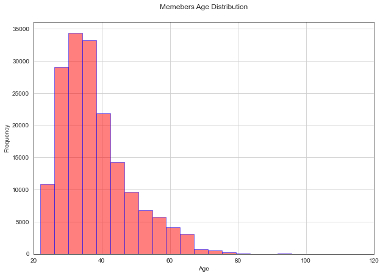

```python
df['age_diff'].hist(bins=30, figsize=(10,7), color='Red', alpha=0.5,edgecolor='blue')
plt.title('Memeber''s Age Distribution',y=1.04)
plt.xlabel('Age', y=0.9)
plt.ylabel('Frequency')
plt.xlim([20,120])
```

### Distribution of duration of ride(seconds)

```python
# Calculate the average ride duration in secs
ride_duration= round(df['duration_sec'].mean(),0)
print('The average ride duration is ' + str(ride_duration) + ' seconds')
```

```
The average ride duration is 704.0 seconds
```

```python
# Calculate the average ride duration in minutes
ride_durations= round(df['duration_sec'].median(),0)
print('The median ride duration is ' + str(ride_durations) + ' seconds')
```

```
The median ride duration is 510.0 seconds
```

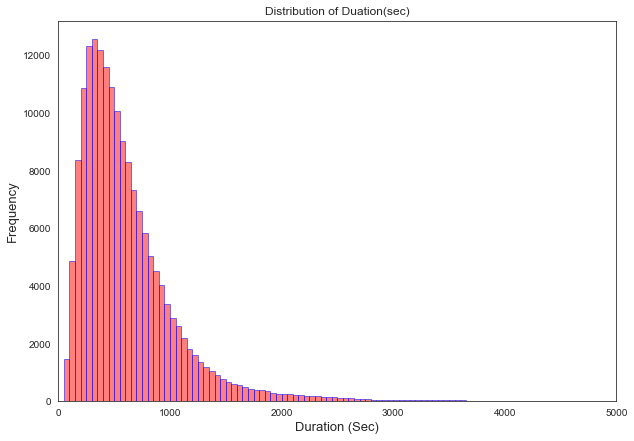

```python
# start with a standard-scaled plot
binsize = 50
bins = np.arange(0, df['duration_sec'].max()+binsize, binsize)

plt.figure(figsize=[10, 7])
plt.hist(data = df, x = 'duration_sec', bins=bins,color='red',edgecolor='blue', alpha=0.5)
plt.xlabel('Duration (Sec)', fontsize=13)
plt.ylabel('Frequency',fontsize=13)
plt.title('Distribution of Duation(sec)')
plt.xlim([0, 5000]);
```

The average ride duration(secs) and median ride duration(secs) for the users is approximately 704 secs and 510 secs respectively

### Number of ride per hour

```python
def mycounting(df,xVar, hue=None, color=0, palette=None,order=None, hue_order=None) :
    ''' This me practicing out looping to avoid repetitive codes'''
    #set plot dimension
    plt.figure(figsize=[14,7])
    #plotting
    sb.countplot(data=df,x=xVar, hue=hue,color=sb.color_palette()[color],palette=palette,order= order,edgecolor='black',hue_order=hue_order,linewidth=2);
    # title and labels
    xVar= xVar.replace('_',' ')
    if hue:
        hue=hue.replace('_',' ')
    #Adding title
    plt.title(f'''Distribution of {xVar} {'by' if hue else ''} {hue if hue else''}'''.title(), fontsize =14, weight ='bold')
    plt.xlabel(xVar.title(), fontsize=10, weight='bold')
    plt.ylabel('Frequency'.title(), fontsize=10, weight='bold')
```

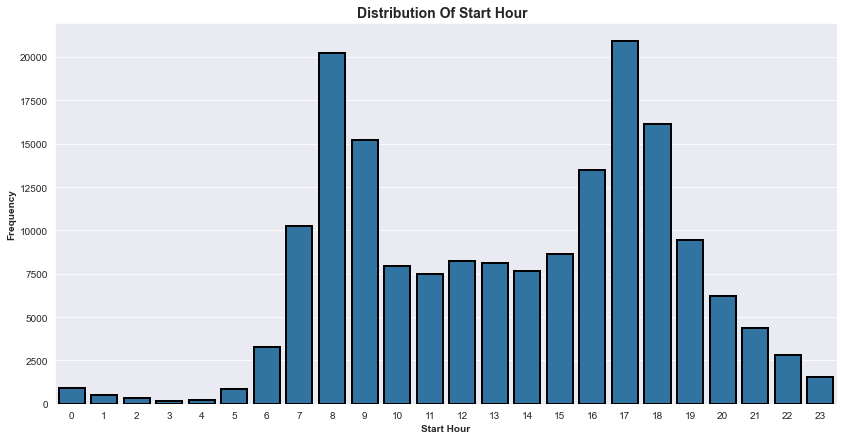

```python
mycounting(df,'start_hour')
```

### Gender Distribution

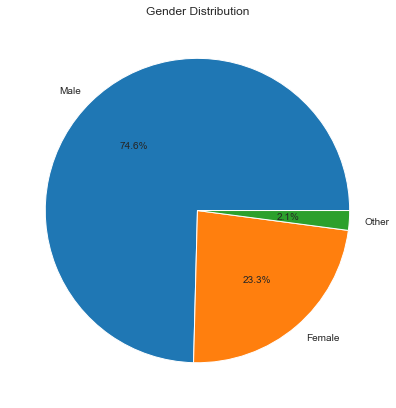

```python
gd= df['member_gender'].value_counts()
gd.plot(kind='pie',autopct='%.1f%%', figsize=(10,7), title='Gender Distribution', ylabel='')
```

Majority of the users are male, surmounting to approximately 75% of the total population